# Cox Model Case Study

Bjarke Hautop

2024-05-12

# Data

We consider the 506-patient prostate cancer dataset from Byar and Green. These data were from a randomized trial comparing four treatments for stage 3 and 4 prostate cancer, with almost equal numbers of patients on placebo and each of three doses of estrogen. Four patients had missing values on all of the following variables: wt, pf, hx, sbp, dbp, ekg, hg, bm; two of these patients were also missing sz. These patients are excluded from consideration.

The primary goal is to discover patterns in survival, and to do an analysis of covariance to assess the effect of treatment while adjusting for patient heterogeneity. Prediction is a secondary goal

We will follow guidelines given in the book Regression Modeling Strategies by Frank Harrell and his general approach to this dataset in Chapter 21. The analysis is expanded compared to what was done in the book.

There are 354 deaths among the 502 patients and we will use a multivariate survival model to explain the time until death (of any cause).

## Loading data

```r
require(Hmisc)
library(survival)
require(rms)
require(scales)
require(ggplot2)
require(latex2exp)
getHdata(prostate)
```

We start by showing summary of all the variables in the dataset

```r
d <- describe(prostate[2:17])
html(d, file='')
```

**Click here to see output**

prostate[2:17]  
16 Variables 502 Observations

stage: Stage

| n | missing | distinct | Info | Mean | Gmd |
| --- | --- | --- | --- | --- | --- |
| 502 | 0 | 2 | 0.733 | 3.424 | 0.4895 |

```
 Value          3     4
 Frequency    289   213
 Proportion 0.576 0.424
```

rx

| n | missing | distinct |
| --- | --- | --- |
| 502 | 0 | 4 |

```
 Value              placebo 0.2 mg estrogen 1.0 mg estrogen 5.0 mg estrogen
 Frequency              127             124             126             125
 Proportion           0.253           0.247           0.251           0.249
```

dtime: Months of Follow-up

| n | missing | distinct | Info | Mean | Gmd | .05 | .10 | .25 | .50 | .75 | .90 | .95 |
| --- | --- | --- | --- | --- | --- | --- | --- | --- | --- | --- | --- | --- |
| 502 | 0 | 76 | 1 | 36.13 | 26.89 | 1.05 | 5.00 | 14.25 | 34.00 | 57.75 | 67.00 | 71.00 |

lowest : 0 1 2 3 4 , highest: 72 73 74 75 76

status

| n | missing | distinct |
| --- | --- | --- |
| 502 | 0 | 10 |

| lowest : | alive | dead - prostatic ca | dead - heart or vascular | dead - cerebrovascular | dead - pulmonary embolus |
| --- | --- | --- | --- | --- | --- |
| highest: | dead - other ca | dead - respiratory disease | dead - other specific non-ca | dead - unspecified non-ca | dead - unknown cause |

age: Age in Years

| n | missing | distinct | Info | Mean | Gmd | .05 | .10 | .25 | .50 | .75 | .90 | .95 |
| --- | --- | --- | --- | --- | --- | --- | --- | --- | --- | --- | --- | --- |
| 501 | 1 | 41 | 0.996 | 71.46 | 7.497 | 56 | 60 | 70 | 73 | 76 | 78 | 80 |

lowest : 48 49 50 51 52 , highest: 84 85 87 88 89

wt: Weight Index = wt(kg)-ht(cm)+200

| n | missing | distinct | Info | Mean | Gmd | .05 | .10 | .25 | .50 | .75 | .90 | .95 |
| --- | --- | --- | --- | --- | --- | --- | --- | --- | --- | --- | --- | --- |
| 500 | 2 | 67 | 0.999 | 99.03 | 14.93 | 77.95 | 82.90 | 90.00 | 98.00 | 107.00 | 116.00 | 123.00 |

lowest : 69 71 72 73 74 , highest: 136 142 145 150 152

pf

| n | missing | distinct |
| --- | --- | --- |
| 502 | 0 | 4 |

```
 Value           normal activity in bed < 50% daytime in bed > 50% daytime
 Frequency                   450                   37                   13
 Proportion                0.896                0.074                0.026

 Value           confined to bed
 Frequency                     2
 Proportion                0.004
```

hx: History of Cardiovascular Disease

| n | missing | distinct | Info | Sum | Mean | Gmd |
| --- | --- | --- | --- | --- | --- | --- |
| 502 | 0 | 2 | 0.733 | 213 | 0.4243 | 0.4895 |

sbp: Systolic Blood Pressure/10

| n | missing | distinct | Info | Mean | Gmd | .05 | .10 | .25 | .50 | .75 | .90 | .95 |
| --- | --- | --- | --- | --- | --- | --- | --- | --- | --- | --- | --- | --- |
| 502 | 0 | 18 | 0.98 | 14.35 | 2.596 | 11 | 12 | 13 | 14 | 16 | 17 | 18 |

```
 Value          8     9    10    11    12    13    14    15    16    17    18    19
 Frequency      1     3    14    27    65    74    98    74    72    34    17    12
 Proportion 0.002 0.006 0.028 0.054 0.129 0.147 0.195 0.147 0.143 0.068 0.034 0.024

 Value         20    21    22    23    24    30
 Frequency      3     2     3     1     1     1
 Proportion 0.006 0.004 0.006 0.002 0.002 0.002
```

For the frequency table, variable is rounded to the nearest 0

dbp: Diastolic Blood Pressure/10

| n | missing | distinct | Info | Mean | Gmd | .05 | .10 | .25 | .50 | .75 | .90 | .95 |
| --- | --- | --- | --- | --- | --- | --- | --- | --- | --- | --- | --- | --- |
| 502 | 0 | 12 | 0.945 | 8.149 | 1.553 | 6 | 6 | 7 | 8 | 9 | 10 | 10 |

```
 Value          4     5     6     7     8     9    10    11    12    13    14    18
 Frequency      4     5    43   107   165    94    66     9     5     2     1     1
 Proportion 0.008 0.010 0.086 0.213 0.329 0.187 0.131 0.018 0.010 0.004 0.002 0.002
```

For the frequency table, variable is rounded to the nearest 0

ekg

| n | missing | distinct |
| --- | --- | --- |
| 494 | 8 | 7 |

| lowest : | normal | benign | rhythmic disturb & electrolyte ch | heart block or conduction def | heart strain |
| --- | --- | --- | --- | --- | --- |
| highest: | rhythmic disturb & electrolyte ch | heart block or conduction def | heart strain | old MI | recent MI |

hg: Serum Hemoglobin (g/100ml)

| n | missing | distinct | Info | Mean | Gmd | .05 | .10 | .25 | .50 | .75 | .90 | .95 |
| --- | --- | --- | --- | --- | --- | --- | --- | --- | --- | --- | --- | --- |
| 502 | 0 | 91 | 1 | 13.45 | 2.16 | 10.2 | 10.7 | 12.3 | 13.7 | 14.7 | 15.8 | 16.4 |

lowest : 5.89941 7 7.19922 7.7998 8.19922 , highest: 17.2969 17.5 17.5977 18.1992 21.1992

sz: Size of Primary Tumor (cm<sup>2</sup>)

| n | missing | distinct | Info | Mean | Gmd | .05 | .10 | .25 | .50 | .75 | .90 | .95 |
| --- | --- | --- | --- | --- | --- | --- | --- | --- | --- | --- | --- | --- |
| 497 | 5 | 55 | 0.998 | 14.63 | 13.05 | 2.0 | 3.0 | 5.0 | 11.0 | 21.0 | 32.0 | 39.2 |

lowest : 0 1 2 3 4 , highest: 54 55 61 62 69

sg: Combined Index of Stage and Hist. Grade

| n | missing | distinct | Info | Mean | Gmd | .05 | .10 | .25 | .50 | .75 | .90 | .95 |
| --- | --- | --- | --- | --- | --- | --- | --- | --- | --- | --- | --- | --- |
| 491 | 11 | 11 | 0.959 | 10.31 | 2.245 | 8 | 8 | 9 | 10 | 11 | 13 | 13 |

```
 Value          5     6     7     8     9    10    11    12    13    14    15
 Frequency      3     8     7    67   137    33   114    26    75     5    16
 Proportion 0.006 0.016 0.014 0.136 0.279 0.067 0.232 0.053 0.153 0.010 0.033
```

For the frequency table, variable is rounded to the nearest 0

ap: Serum Prostatic Acid Phosphatase

| n | missing | distinct | Info | Mean | Gmd | .05 | .10 | .25 | .50 | .75 | .90 | .95 |
| --- | --- | --- | --- | --- | --- | --- | --- | --- | --- | --- | --- | --- |
| 502 | 0 | 128 | 0.996 | 12.18 | 21.71 | 0.300 | 0.300 | 0.500 | 0.700 | 2.975 | 21.689 | 38.470 |

| lowest : | 0.0999908 | 0.199982 | 0.299988 | 0.399963 | 0.5 |
| --- | --- | --- | --- | --- | --- |
| highest: | 316 | 353.5 | 367 | 596 | 999.875 |

bm: Bone Metastases

| n | missing | distinct | Info | Sum | Mean | Gmd |
| --- | --- | --- | --- | --- | --- | --- |
| 502 | 0 | 2 | 0.41 | 82 | 0.1633 | 0.2739 |

[output not shown]

## Imputing missing values

The proportion of missing values is $0.05$, so we just do single imputation, since simpler to make plots and validation. However if the proportion were higher one should do multiple imputation.

```r
sum(is.na(prostate))
```

```
## [1] 27
```

```r
colSums(is.na(prostate))
```

```
##  patno  stage     rx  dtime status    age     wt     pf
##      0      0      0      0      0      1      2      0
##     hx    sbp    dbp    ekg     hg     sz     sg     ap
##      0      0      0      8      0      5     11      0
##     bm  sdate
##      0      0
```

```r
w <- transcan(~ sz + sg + ap + sbp + dbp + age +
                wt + hg + ekg + pf + bm + hx, imputed= TRUE,
             data=prostate, pl= FALSE, pr= FALSE)

attach(prostate)
sz <- impute(w, sz, data = prostate)
sg <- impute (w, sg , data = prostate)
age <- impute (w, age ,data = prostate)
wt <- impute (w, wt , data = prostate)
kg <- impute (w, ekg ,data = prostate)
```

# Specifying the model

A Cox proportional hazards model is in terms of the hazard function given by:
$$\lambda(t\vert
X)=\lambda(t)\exp(X\beta).$$
We fit a Cox proportional hazards model with the predictors and their degrees of freedom specified in the table below. All continuous predictors will be modeled with a restricted cubic spline with 4 knots.

| Predictor | Name | d.f. | Levels |
| --- | --- | --- | --- |
| Dose of estrogen | rx | 3 | placebo, 0.2, 1.0, 5.0 mg estrogen |
| Age in years | age | 3 |  |
| Weight index | wt | 3 |  |
| Performance rating | pf | 2 | normal, in bed < 50% of time, in bed > 50% |
| History of cardiovascular disease | hx | 1 | present/absent |
| Systolic blood pressure/10 | sbp | 3 |  |
| Diastolic blood pressure/10 | dbp | 3 |  |
| Electrocardiogram code | ekg | 5 | normal, benign, rhythm disturb., block, strain, myocardial infarction |
| Serum hemoglobin (g/100ml) | hg | 3 |  |
| Tumor size (cm^2) | sz | 3 |  |
| Stage/histologic grade combination | sg | 3 |  |
| Serum prostatic acid phosphatase | ap | 3 |  |
| Bone metastasis | bm | 1 | present/absent |

We see that we have 36 degrees of freedom in our model, so about 1/10 of the amount of deaths there are. So there is some hope our model will validate.

```r
dd <- datadist(prostate); options(datadist='dd')
units(dtime) <- 'Month'
S <- Surv(dtime , status != 'alive')

f <- cph(S ~ rx + rcs(age ,4) + rcs(wt ,4) + pf + hx +
          rcs(sbp ,4) + rcs(dbp ,4) + ekg + rcs(hg ,4) +
          rcs(sg ,4) + rcs(sz ,4) + rcs(log(ap),4) + bm)
print(f, html=TRUE, coefs=FALSE)
```

```
## Frequencies of Missing Values Due to Each Variable
##   S  rx age  wt  pf  hx sbp dbp ekg  hg  sg  sz  ap  bm
##   0   0   0   0   0   0   0   0   8   0   0   0   0   0
##
## Cox Proportional Hazards Model
##
## cph(formula = S ~ rx + rcs(age, 4) + rcs(wt, 4) + pf + hx + rcs(sbp,
##     4) + rcs(dbp, 4) + ekg + rcs(hg, 4) + rcs(sg, 4) + rcs(sz,
##     4) + rcs(log(ap), 4) + bm)
##
##
##                         Model Tests     Discrimination
##                                                Indexes
## Obs        494    LR chi2    136.04     R2       0.241
## Events     348    d.f.           36    R2(36,494)0.183
## Center -2.0435    Pr(> chi2) 0.0000    R2(36,348)0.250
##                   Score chi2 144.95     Dxy      0.338
##                   Pr(> chi2) 0.0000
```

Test for removing all predictors is highly significant, so modelling is warranted. AIC on the $\chi^2$-scale is given by $136.04-2\cdot 36=64.04$. A rough shrinkage estimate is thus given by $(136.04-36)/136.04=0.74$. So we estimate that 0.26 of the model fitting will be noise, especially with regard to calibration accuracy. One approach would just be to multiply coefficients of final model if used for prediction by the shrinkage estimate. Instead we try to do some data reduction using domain knowledge.

## Data reduction using domain knowledge

We do the following changes

- Combine systolic blood pressure (sbp) and diastolic blood pressure (dbp) into Mean Arterial Pressure.
- Combine history of cardiovascular disease (hx) and electrocardiogram code ekg and assume linear. We code it as 2 if ekg are not normal or benign and hx, 1 if either, and 0 if none.
- Weight index not that important, so only use 3 knots.
- Take log of Serum prostatic acid phosphatase (ap) for numeric stability (heavy right-tail) and allow 1 more knot for compensation
- The tumor variables tumor size (sz) and stage/histologic grade combination (sg) should be important variables, but since we have both we keep them but give them only 3 knots each.
- Assume performance rating (pf) is linear.

```r
map <- (2*dbp + sbp)/3
label(map) <- 'Mean Arterial Pressure/10'

heart_d <- hx + ekg %nin% c('normal', 'benign')
label(heart_d) <- 'Heart Disease Code'

pf_linear <- as.numeric(pf)
```

```r
dd <- datadist(dd, heart_d, map, pf_linear)

f <- cph(S ~ rx + rcs(age, 4) + rcs(wt, 3) + pf_linear + heart_d + rcs(map, 3)
         + rcs(hg, 4) + rcs(sg, 3) + rcs(sz, 3) + rcs(log(ap), 5) + bm,
         x=TRUE , y=TRUE , surv=TRUE , time.inc = 5*12)

print(f, html=TRUE, coefs =3)
```

```
## Cox Proportional Hazards Model
##
## cph(formula = S ~ rx + rcs(age, 4) + rcs(wt, 3) + pf_linear +
##     heart_d + rcs(map, 3) + rcs(hg, 4) + rcs(sg, 3) + rcs(sz,
##     3) + rcs(log(ap), 5) + bm, x = TRUE, y = TRUE, surv = TRUE,
##     time.inc = 5 * 12)
##
##                         Model Tests     Discrimination
##                                                Indexes
## Obs        502    LR chi2    119.86     R2       0.212
## Events     354    d.f.           24    R2(24,502)0.174
## Center -2.3792    Pr(> chi2) 0.0000    R2(24,354)0.237
##                   Score chi2 126.89     Dxy      0.323
##                   Pr(> chi2) 0.0000
##
##                    Coef     S.E.    Wald Z Pr(>|Z|)
## rx=0.2 mg estrogen   0.0005  0.1492  0.00  0.9975
## rx=1.0 mg estrogen  -0.4136  0.1659 -2.49  0.0127
## rx=5.0 mg estrogen  -0.1044  0.1572 -0.66  0.5066
## . . .
```

LR 119.86 with 24 degrees of freedom. AIC is $119.86-2 \cdot 24=71.86$. Rough shrinkage estimate of this is now better at $(119.86-24)/119.86=0.80$.

```r
anova(f, html=T)
```

```
##                 Wald Statistics          Response: S
##
##  Factor          Chi-Square d.f. P
##  rx                7.92      3   0.0476
##  age              13.65      3   0.0034
##   Nonlinear        8.94      2   0.0115
##  wt                8.23      2   0.0163
##   Nonlinear        2.57      1   0.1092
##  pf_linear         3.50      1   0.0615
##  heart_d          24.91      1   <.0001
##  map               0.05      2   0.9753
##   Nonlinear        0.05      1   0.8232
##  hg               12.49      3   0.0059
##   Nonlinear        8.10      2   0.0174
##  sg                1.70      2   0.4269
##   Nonlinear        0.05      1   0.8318
##  sz               12.43      2   0.0020
##   Nonlinear        0.07      1   0.7888
##  ap                6.46      4   0.1672
##   Nonlinear        6.16      3   0.1042
##  bm                0.03      1   0.8523
##  TOTAL NONLINEAR  23.58     11   0.0146
##  TOTAL           120.27     24   <.0001
```

We see that the p-value for the treatment, doses of estrogen (rx), is below $0.05$, so it seems like it has some effect.

## Checking Proportional Hazards

A Cox model should have proportional hazards, since if we look at two individuals with covariate values $\boldsymbol{X}$ and $\boldsymbol{X}^*$ then the ratio of their hazard rates is
$$\frac{h(t \vert
\boldsymbol{X})}{h(t \vert \boldsymbol{X}^*)}=\exp\Big[\sum_{k=1}^p
\beta_k(X_k-X_{k^*})\Big],$$
which is a constant. We can test this assumption using scaled Schoenfeld residuals separately for each predictor and test the PH assumption using the “correlation with time” test. Smoothed trends in the residuals are also plotted.

```r
z <- predict(f, type = 'terms')
f.short <- cph(S ~ z, x=TRUE, y= TRUE)
phtest <- cox.zph(f.short, transform = 'identity', terms=F)
phtest
```

```
##              chisq df     p
## rx        3.906254  1 0.048
## age       1.218347  1 0.270
## wt        0.016868  1 0.897
## pf_linear 0.190007  1 0.663
## heart_d   0.360714  1 0.548
## map       0.046079  1 0.830
## hg        0.018155  1 0.893
## sg        0.904761  1 0.342
## sz        0.218858  1 0.640
## ap        0.009228  1 0.923
## bm        0.000329  1 0.986
## GLOBAL    7.813453 11 0.730
```

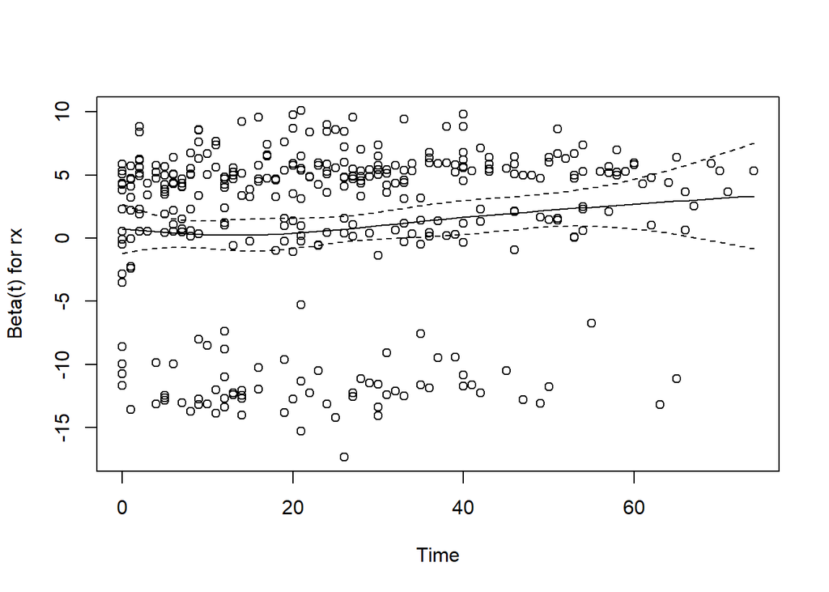

```r
plot(phtest , var= 'rx')
```

## Describing Effects

We plot how each predictor is related to the log hazard of death with $95\%$-confidence bands.

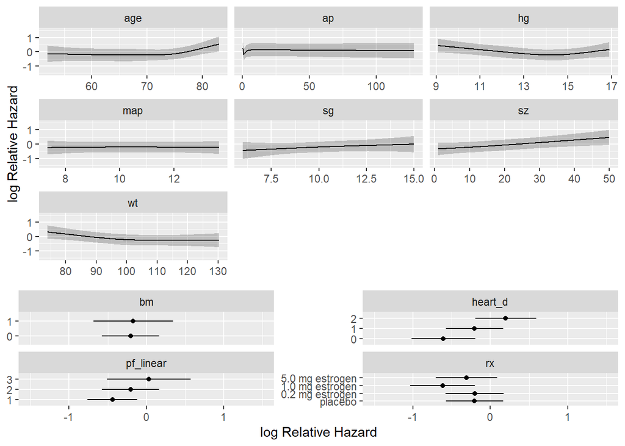

```r
ggplot(Predict(f), sepdiscrete='vertical', nlevels=4,
vnames='names')
```

# Presenting the final Model for inference

To present point and interval estimates of predictor effects we draw a hazard ratio chart. Since the ap relationship is so non-monotonic we use a 20:1 hazard ratio for this variable. The others use the default.

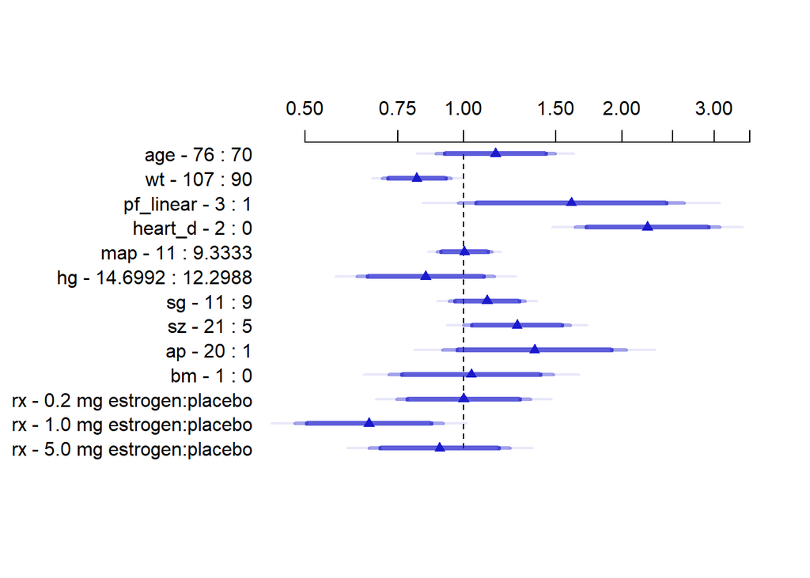

```r
plot(summary(f, ap=c(1,20)), log=TRUE, main='')
```

Finally we will also show a nomogram.

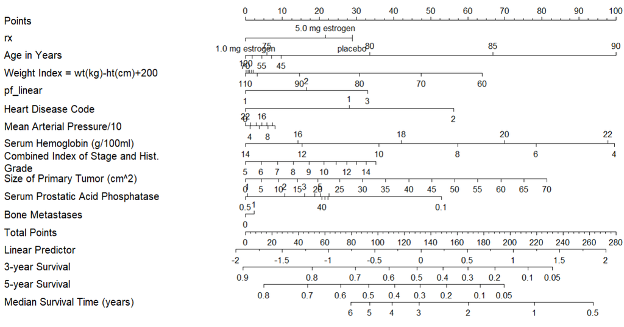

```r
surv <- Survival(f)
surv3 <- function (x) surv(3*12,lp=x)
surv5 <- function (x) surv(5*12,lp=x)
quan <- Quantile(f)
med <- function (x) quan(lp=x)/12
ss <- c(.05 ,.1, .2, .3, .4, .5, .6, .7, .8, .9, .95)
nom <- nomogram (f, ap=c(.1,.5, 1, 2, 3, 4, 5, 10, 20, 30, 40),
                 fun=list(surv3, surv5, med),
                 funlabel=c('3-year Survival', '5-year Survival',
                              'Median Survival Time (years)'),
                 fun.at=list(ss, ss, c(.5, 1:6)))
plot(nom, cex.axis=0.8, cex.var=0.7, xfrac=.65, lmgp=.35)
```

This is interpreted by taking a value for each predictor and seeing how many points each value correspond to. Then the total amount of points can be used to find the probability of for example 5-year survival.

# Model for prediction

For a prediction model one should validate the model. We start by doing that

## Validating the model

We will use bootstrapping for validation. We first validate this model for Somers’ $D_xy$ rank correlation between predicted log hazard and observed survival time, and for slope shrinkage. The bootstrap is used (with 1000 resamples) to penalize for possible overfitting.

```r
v <- validate(f, B=1000)
options(prType='html')
v
```

| Index | Original Sample | Training Sample | Test Sample | Optimism | Corrected Index | Successful Resamples |
| --- | --- | --- | --- | --- | --- | --- |
| *D<sub>xy</sub>* | 0.3228 | 0.3497 | 0.298 | 0.0517 | 0.2712 | 1000 |
| *R<sup>2</sup>* | 0.2125 | 0.2498 | 0.1777 | 0.0721 | 0.1404 | 1000 |
| Slope | 1 | 1 | 0.7888 | 0.2112 | 0.7888 | 1000 |
| *D* | 0.0296 | 0.0357 | 0.0242 | 0.0115 | 0.018 | 1000 |
| *U* | -5e-04 | -5e-04 | 0.0024 | -0.0029 | 0.0024 | 1000 |
| *Q* | 0.0301 | 0.0362 | 0.0218 | 0.0144 | 0.0157 | 1000 |
| *g* | 0.7245 | 0.8075 | 0.6347 | 0.1729 | 0.5516 | 1000 |

Here “training” refers to accuracy when evaluated on the bootstrap sample used to fit the model, and “test” refers to the accuracy when this model is applied without modification to the original sample. The apparent $D_xy$ is 0.32, but a better estimate of how well the model will discriminate prognoses in the future is $D_xy = 0.27$. The bootstrap estimate of slope shrinkage is 0.79, close to the simple heuristic estimate.

### Validate the model for predicting the probability of surviving five years

We will use the non-shrinked estimates to show that this model will have some overfitting consistent with *regression to the mean*.

```r
cal <- calibrate(f, B = 1000, u=5*12)
```

```
## Using Cox survival estimates at 60 Months
## Convergence problems.... stopping addition
## Convergence problems.... stopping addition
## Convergence problems.... stopping addition
## Convergence problems.... stopping addition
## Convergence problems.... stopping addition
## Convergence problems.... stopping addition
## Convergence problems.... stopping addition
```

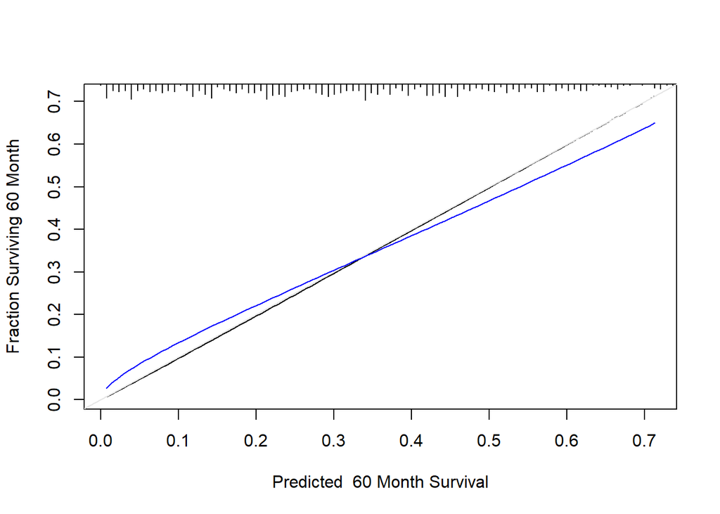

```r
plot(cal, subtitles= FALSE)
```

The line nearer the ideal line corresponds to apparent predictive accuracy. The blue curve corresponds to bootstrap-corrected estimates. We clearly see some regression to the mean.

## Final model for prediction

For a better model for prediction one should multiply the coefficients in the model by the shrinkage estimate.

```r
v
```

| Index | Original Sample | Training Sample | Test Sample | Optimism | Corrected Index | Successful Resamples |
| --- | --- | --- | --- | --- | --- | --- |
| *D<sub>xy</sub>* | 0.3228 | 0.3497 | 0.298 | 0.0517 | 0.2712 | 1000 |
| *R<sup>2</sup>* | 0.2125 | 0.2498 | 0.1777 | 0.0721 | 0.1404 | 1000 |
| Slope | 1 | 1 | 0.7888 | 0.2112 | 0.7888 | 1000 |
| *D* | 0.0296 | 0.0357 | 0.0242 | 0.0115 | 0.018 | 1000 |
| *U* | -5e-04 | -5e-04 | 0.0024 | -0.0029 | 0.0024 | 1000 |
| *Q* | 0.0301 | 0.0362 | 0.0218 | 0.0144 | 0.0157 | 1000 |
| *g* | 0.7245 | 0.8075 | 0.6347 | 0.1729 | 0.5516 | 1000 |

```r
shrinkage_est <- v[3, 5] # Extract bootstrap estimate of shrinkage
f_prediction <- f
f_prediction$coefficients <- f$coefficients*shrinkage_est

print(f_prediction, html=T, coef=3)
```

**Cox Proportional Hazards Model**

```
cph(formula = S ~ rx + rcs(age, 4) + rcs(wt, 3) + pf_linear +
    heart_d + rcs(map, 3) + rcs(hg, 4) + rcs(sg, 3) + rcs(sz,
    3) + rcs(log(ap), 5) + bm, x = TRUE, y = TRUE, surv = TRUE,
    time.inc = 5 * 12)
```

|  | Model Tests | Discrimination Indexes |
| --- | --- | --- |
| Obs 502 | LR χ<sup>2</sup> 119.86 | *R*<sup>2</sup> 0.212 |
| Events 354 | d.f. 24 | *R*<sup>2</sup><sub>24,502</sub> 0.174 |
| Center -2.3792 | Pr(>χ<sup>2</sup>) 0.0000 | *R*<sup>2</sup><sub>24,354</sub> 0.237 |
|  | Score χ<sup>2</sup> 126.89 | *D*<sub>xy</sub> 0.323 |
|  | Pr(>χ<sup>2</sup>) 0.0000 |  |

|  | β | S.E. | Wald *Z* | Pr(>\|*Z*\|) |
| --- | --- | --- | --- | --- |
| rx=0.2 mg estrogen | 0.0004 | 0.1492 | 0.00 | 0.9980 |
| rx=1.0 mg estrogen | -0.3262 | 0.1659 | -1.97 | 0.0493 |
| rx=5.0 mg estrogen | -0.0823 | 0.1572 | -0.52 | 0.6004 |
| … |  |  |  |  |

### Approximating the full model

If the client doesn’t want to collect all these variables for prediction we can do model approximation. The goal is to explain `f_prediction`with a trade off between parameters and $R^2$. This can be done by backwards selection.

```r
Z <- predict(f_prediction) # compute linear predictor from full model

# Force sigma to be 1 since perfect fit
a <- ols(Z ~ rx + rcs(age, 4) + rcs(wt, 3) + pf_linear + heart_d + rcs(map, 3)
         + rcs(hg, 4) + rcs(sg, 3) + rcs(sz, 3) + rcs(log(ap), 5) + bm, sigma =1)

backwards <- fastbw(a, aics=10000)
print(backwards, html=T, digits=3)
```

```
##
##  Deleted   Chi-Sq d.f. P      Residual d.f. P      AIC
##  map        0.07  2    0.9641   0.07    2   0.9641  -3.93
##  bm         0.04  1    0.8321   0.12    3   0.9896  -5.88
##  sg         2.50  2    0.2861   2.62    5   0.7582  -7.38
##  pf_linear  4.88  1    0.0271   7.51    6   0.2767  -4.49
##  rx        15.66  3    0.0013  23.16    9   0.0058   5.16
##  wt        12.41  2    0.0020  35.57   11   0.0002  13.57
##  age       16.50  3    0.0009  52.08   14   0.0000  24.08
##  ap        19.61  4    0.0006  71.69   18   0.0000  35.69
##  hg        36.53  3    0.0000 108.22   21   0.0000  66.22
##  sz        42.83  2    0.0000 151.04   23   0.0000 105.04
##  heart_d   55.27  1    0.0000 206.31   24   0.0000 158.31
##  R2
##  1.000
##  0.999
##  0.987
##  0.964
##  0.888
##  0.828
##  0.748
##  0.653
##  0.475
##  0.268
##  0.000
##
## Approximate Estimates after Deleting Factors
##
##          Coef   S.E.  Wald Z P
## [1,] 6.68e-11 0.0446 1.5e-09 1
##
## Factors in Final Model
##
## None
```

Now the client can choose the trade-off between predictive ability and number of predictors. We visualize this in the following plot

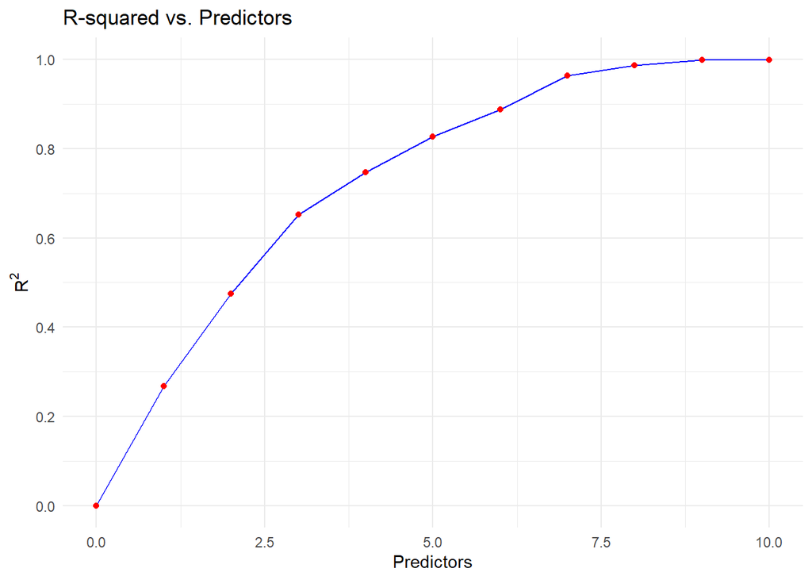

```r
result <- as.data.frame(backwards$result)
total_predictors <- nrow(result)
R2 <- result$R2
predictors <- c((total_predictors-1):0)

ggplot(data.frame(predictors,R2), aes(x = predictors, y = R2)) +
  geom_line(color = "blue") +
  geom_point(color = "red") +
  labs(x = "Predictors", y = TeX("$R^2$")) +
  ggtitle("R-squared vs. Predictors") +
  scale_y_continuous(breaks= pretty_breaks()) +
  theme_minimal()
```

A reasonable approach trade off would be to remove map, bm, sg and pf_linear from our model to get an approximate model which still has high $R^2$ of $0.96$ for explaining the full model.

```r
f_approx <- ols(Z ~ rx + rcs(age, 4) + rcs(wt, 3) + heart_d
         + rcs(hg, 4) + rcs(sz, 3) + rcs(log(ap), 5), x=T)

print(f_approx, html=T, coefs=3)
```

**Linear Regression Model**

```
ols(formula = Z ~ rx + rcs(age, 4) + rcs(wt, 3) + heart_d + rcs(hg,
    4) + rcs(sz, 3) + rcs(log(ap), 5), x = T)
```

|  | Model Likelihood Ratio Test | Discrimination Indexes |
| --- | --- | --- |
| Obs 502 | LR χ<sup>2</sup> 1663.53 | *R*<sup>2</sup> 0.964 |
| σ 0.1247 | d.f. 18 | *R*<sup>2</sup><sub>adj</sub> 0.962 |
| d.f. 483 | Pr(>χ<sup>2</sup>) 0.0000 | *g* 0.713 |

Residuals

```
     Min       1Q   Median       3Q      Max
-0.30962 -0.07092 -0.02333  0.04420  0.63137
```

|  | β | S.E. | *t* | Pr(>\|*t*\|) |
| --- | --- | --- | --- | --- |
| Intercept | 3.7212 | 0.1976 | 18.83 | <0.0001 |
| rx=0.2 mg estrogen | 0.0070 | 0.0158 | 0.44 | 0.6600 |
| rx=1.0 mg estrogen | -0.4338 | 0.0159 | -27.32 | <0.0001 |
| … |  |  |  |  |

# Conclusion

We devolved a Cox proportional hazards model to explain time until death (of any cause) for this dataset. We described the effects the predictors in the model had by various plots.

We did validation and calibration if one wished to use the model for prediction, to avoid issues such as regression to the mean. We then developed a simplified model which dropped 4 predictors, but could still predict the full model with high accuracy ($R^2=0.964)$.

Throughout we used the guidelines of Regression Modelling Strategies to follow sounds statistical strategies when building and validating a model.